# CLT Convergence: Exponential

```r
source("../R/clt_functions.R")

student_id <- 8515     # last 4 digits of my student ID
B          <- 10000    # number of simulated samples (NOT the sample size)
pop        <- "exponential"
```

## 1. What does the population look like?

X ~ Exponential(rate = 1), generated with `rexp()`. Strong right skew (population skewness = 2).

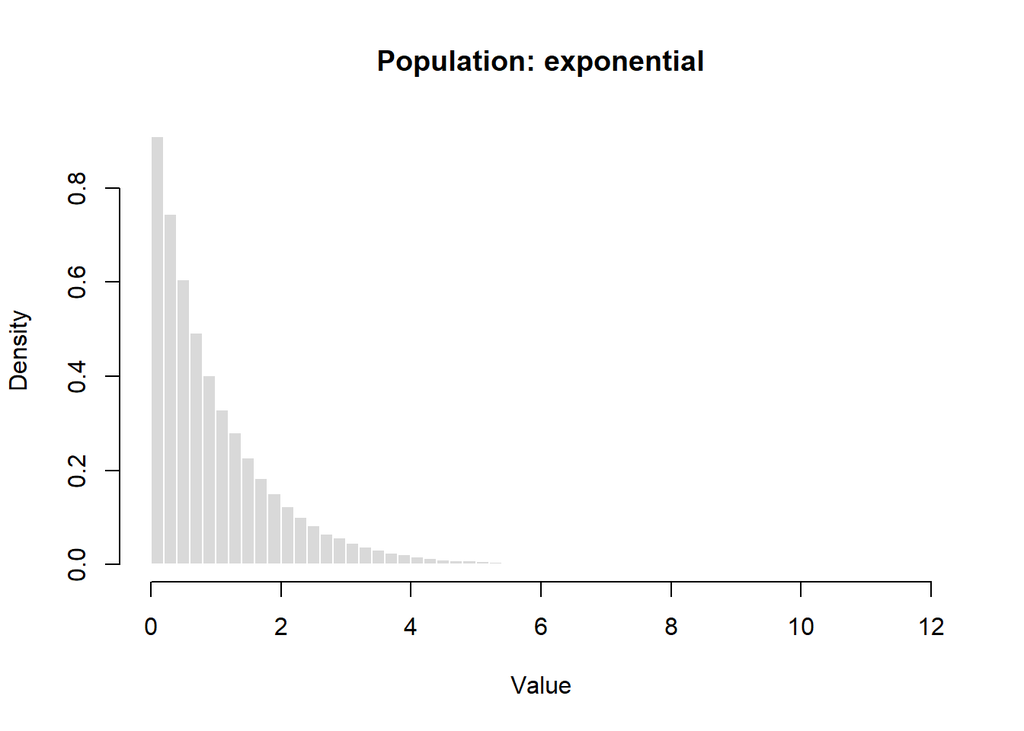

```r
plot_population(pop, seed = student_id)
```

The population is continuous and only takes positive values. Most values are bunched near 0, and the right tail stretches past 5, so it is strongly right-skewed (skewness = 2) and looks nothing like a bell curve. It still has a finite mean and variance and the draws are independent, so the CLT applies. I expect it to work slowly because of the skew.

## 2. Theoretical mean and standard deviation

Theoretical mean = 1, SD = 1, so SE(X̄) = 1/√n.

## 3. Prediction (write this BEFORE running the simulations)

The exponential population is strongly right-skewed (skewness = 2) with a long right tail, so I expect the sample means to stay right-skewed at small n. Since this population is more skewed than what the “n = 30” rule assumes, I predict it will take more than 30, around n = 50–100, before the histogram looks symmetric and the Q-Q plot is straight. I expect the simulated mean to stay near 1 and the simulated SE to match 1/√n at every n, since those CLT formulas don’t depend on the population’s shape.

## 4. Which sample sizes did I investigate?

**Pass 1 (coarse):** a wide grid to find roughly where the change happens.

```r
ns_coarse <- c(2, 5, 10, 20, 30, 50, 100, 200, 500)
coarse    <- run_study(pop, ns_coarse, B = B, seed = student_id)
knitr::kable(coarse$table, digits = 4)
```

| n | sim_mean | theo_mean | sim_se | theo_se | se_ratio | skewness | ex_kurt | qq_cor | shapiro_p |
| --- | --- | --- | --- | --- | --- | --- | --- | --- | --- |
| 2 | 1.0105 | 1 | 0.7152 | 0.7071 | 1.0115 | 1.4392 | 3.1537 | 0.9466 | 0.0000 |
| 5 | 1.0101 | 1 | 0.4545 | 0.4472 | 1.0163 | 0.9532 | 1.4424 | 0.9760 | 0.0000 |
| 10 | 1.0026 | 1 | 0.3186 | 0.3162 | 1.0075 | 0.6090 | 0.5153 | 0.9896 | 0.0000 |
| 20 | 0.9998 | 1 | 0.2237 | 0.2236 | 1.0006 | 0.4278 | 0.2123 | 0.9948 | 0.0000 |
| 30 | 0.9990 | 1 | 0.1825 | 0.1826 | 0.9998 | 0.3611 | 0.1188 | 0.9962 | 0.0000 |
| 50 | 0.9999 | 1 | 0.1404 | 0.1414 | 0.9930 | 0.2629 | -0.0124 | 0.9979 | 0.0000 |
| 100 | 0.9996 | 1 | 0.0996 | 0.1000 | 0.9962 | 0.2037 | 0.0583 | 0.9988 | 0.0000 |
| 200 | 1.0000 | 1 | 0.0714 | 0.0707 | 1.0093 | 0.1107 | 0.0046 | 0.9996 | 0.0002 |
| 500 | 1.0004 | 1 | 0.0452 | 0.0447 | 1.0104 | 0.0589 | 0.0424 | 0.9999 | 0.7425 |

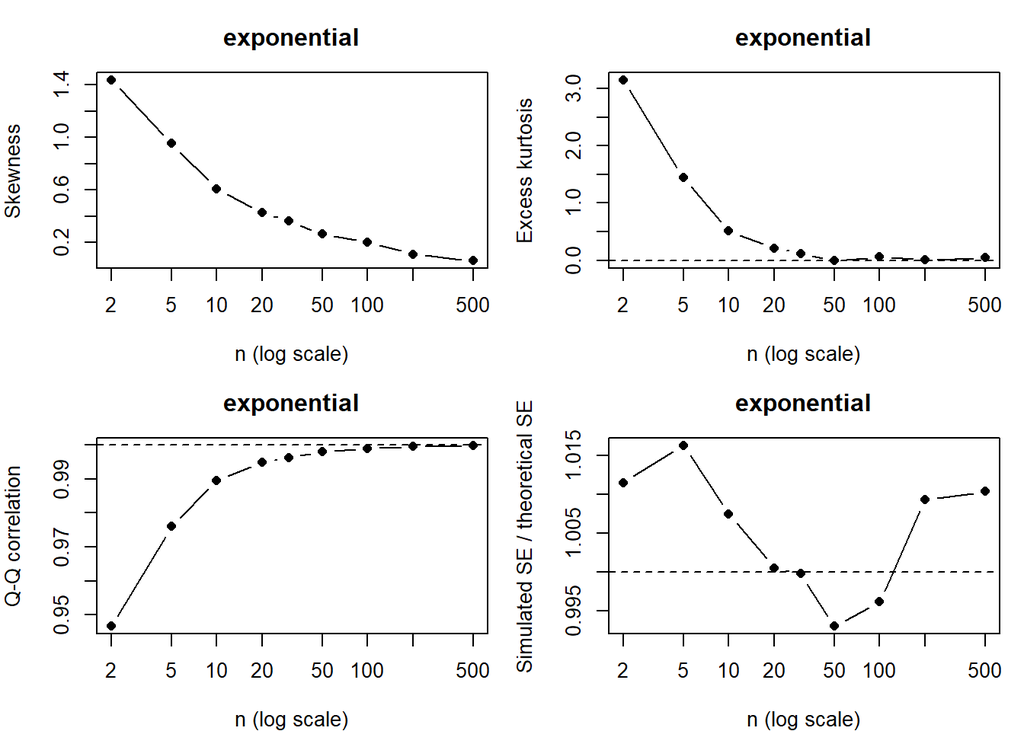

```r
plot_convergence(coarse$table, pop)
```

**Pass 2 (refined):** narrower values around the transition.

```r
ns_fine <- c(60, 70, 80, 90, 100, 125, 150)
fine    <- run_study(pop, ns_fine, B = B, seed = student_id)
knitr::kable(fine$table, digits = 4)
```

| n | sim_mean | theo_mean | sim_se | theo_se | se_ratio | skewness | ex_kurt | qq_cor | shapiro_p |
| --- | --- | --- | --- | --- | --- | --- | --- | --- | --- |
| 60 | 0.9997 | 1 | 0.1289 | 0.1291 | 0.9985 | 0.2956 | 0.0780 | 0.9974 | 0 |
| 70 | 1.0001 | 1 | 0.1204 | 0.1195 | 1.0078 | 0.2831 | 0.0243 | 0.9976 | 0 |
| 80 | 0.9999 | 1 | 0.1119 | 0.1118 | 1.0005 | 0.2284 | -0.0104 | 0.9984 | 0 |
| 90 | 0.9999 | 1 | 0.1058 | 0.1054 | 1.0035 | 0.2025 | -0.0057 | 0.9987 | 0 |
| 100 | 0.9996 | 1 | 0.0996 | 0.1000 | 0.9962 | 0.2037 | 0.0583 | 0.9988 | 0 |
| 125 | 0.9997 | 1 | 0.0889 | 0.0894 | 0.9943 | 0.1704 | -0.0346 | 0.9991 | 0 |
| 150 | 0.9997 | 1 | 0.0816 | 0.0816 | 0.9998 | 0.1563 | 0.0445 | 0.9993 | 0 |

Pass 1 showed skewness falling steadily but still above my 0.25 cutoff at n = 50 (0.26) and passing by n = 100 (0.20). Kurtosis met its cutoff by n = 20, so skewness and the Q-Q correlation were the criteria that limited this population. I refined between 60 and 150 to find where they cross their cutoffs. Both first passed at n = 80 and stayed passing at every larger n.

## 5. Simulated vs. theoretical mean and standard error

The table columns `sim_mean` / `theo_mean` and `sim_se` / `theo_se` compare the simulation with the CLT’s predictions. `se_ratio` = simulated SE ÷ σ/√n, so 1 means a perfect match.

The simulated mean was within about 0.01 of the theoretical mean of 1 at every n, including n = 2. The SE ratio stayed between 0.99 and 1.02 at every n, so σ/√n described the spread of the sample means even at n = 2, where the distribution was clearly not normal. The mean and SE formulas don’t depend on normality. Only the shape of the sampling distribution needs a large n.

## 6. My “normal enough” standard and the chosen n

```r
#  My "normal enough" standard, used identically in every file
criteria <- list(
  max_abs_skew = 0.25,    # mild skew; tighter is within Monte Carlo noise
  max_abs_kurt = 0.3,     # tails close to normal
  min_qq_cor   = 0.998    # Q-Q plot essentially straight
)

all_results <- rbind(coarse$table, fine$table)
all_results <- all_results[!duplicated(all_results$n), ]
all_results <- all_results[order(all_results$n), ]
all_results$passes <- passes_standard(all_results, criteria)
knitr::kable(all_results, digits = 4)
```

|  | n | sim_mean | theo_mean | sim_se | theo_se | se_ratio | skewness | ex_kurt | qq_cor | shapiro_p | passes |
| --- | --- | --- | --- | --- | --- | --- | --- | --- | --- | --- | --- |
| 1 | 2 | 1.0105 | 1 | 0.7152 | 0.7071 | 1.0115 | 1.4392 | 3.1537 | 0.9466 | 0.0000 | FALSE |
| 2 | 5 | 1.0101 | 1 | 0.4545 | 0.4472 | 1.0163 | 0.9532 | 1.4424 | 0.9760 | 0.0000 | FALSE |
| 3 | 10 | 1.0026 | 1 | 0.3186 | 0.3162 | 1.0075 | 0.6090 | 0.5153 | 0.9896 | 0.0000 | FALSE |
| 4 | 20 | 0.9998 | 1 | 0.2237 | 0.2236 | 1.0006 | 0.4278 | 0.2123 | 0.9948 | 0.0000 | FALSE |
| 5 | 30 | 0.9990 | 1 | 0.1825 | 0.1826 | 0.9998 | 0.3611 | 0.1188 | 0.9962 | 0.0000 | FALSE |
| 6 | 50 | 0.9999 | 1 | 0.1404 | 0.1414 | 0.9930 | 0.2629 | -0.0124 | 0.9979 | 0.0000 | FALSE |
| 10 | 60 | 0.9997 | 1 | 0.1289 | 0.1291 | 0.9985 | 0.2956 | 0.0780 | 0.9974 | 0.0000 | FALSE |
| 11 | 70 | 1.0001 | 1 | 0.1204 | 0.1195 | 1.0078 | 0.2831 | 0.0243 | 0.9976 | 0.0000 | FALSE |
| 12 | 80 | 0.9999 | 1 | 0.1119 | 0.1118 | 1.0005 | 0.2284 | -0.0104 | 0.9984 | 0.0000 | TRUE |
| 13 | 90 | 0.9999 | 1 | 0.1058 | 0.1054 | 1.0035 | 0.2025 | -0.0057 | 0.9987 | 0.0000 | TRUE |
| 7 | 100 | 0.9996 | 1 | 0.0996 | 0.1000 | 0.9962 | 0.2037 | 0.0583 | 0.9988 | 0.0000 | TRUE |
| 15 | 125 | 0.9997 | 1 | 0.0889 | 0.0894 | 0.9943 | 0.1704 | -0.0346 | 0.9991 | 0.0000 | TRUE |
| 16 | 150 | 0.9997 | 1 | 0.0816 | 0.0816 | 0.9998 | 0.1563 | 0.0445 | 0.9993 | 0.0000 | TRUE |
| 8 | 200 | 1.0000 | 1 | 0.0714 | 0.0707 | 1.0093 | 0.1107 | 0.0046 | 0.9996 | 0.0002 | TRUE |
| 9 | 500 | 1.0004 | 1 | 0.0452 | 0.0447 | 1.0104 | 0.0589 | 0.0424 | 0.9999 | 0.7425 | TRUE |

```r
smallest_normal_n(all_results, criteria)
```

```
[1] 80
```

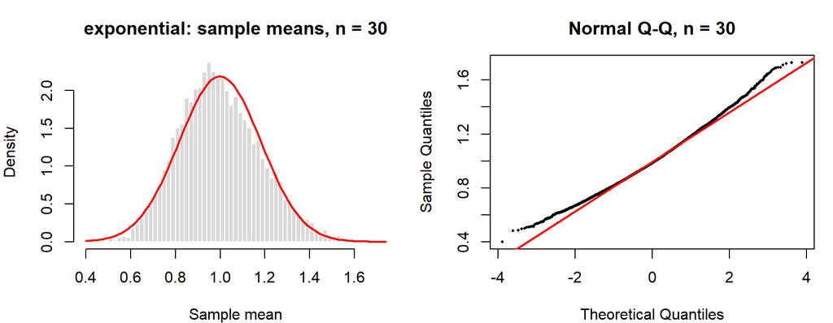

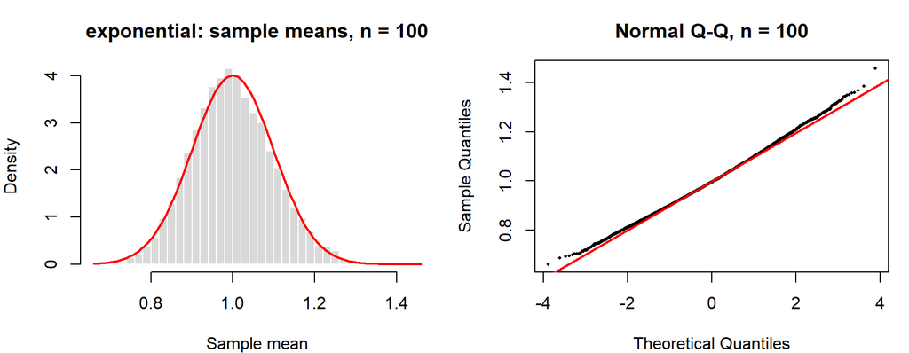

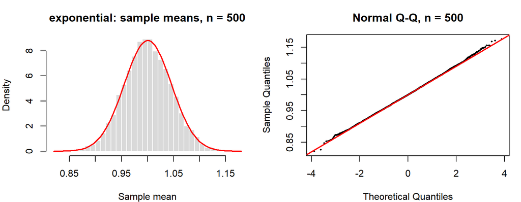

```r
# Show values below, at, and above your chosen n
for (n in c(30, 100, 500)) {   # below, at, and above my chosen n
  plot_diagnostics(simulate_means(populations[[pop]], n, B, student_id), n, pop)
}
```

$$\boxed{n = \text{80}}$$

My standard: the sampling distribution is “normal enough” when |skewness| ≤ 0.25, |excess kurtosis| ≤ 0.3, and the Q-Q correlation is ≥ 0.998, confirmed by a Q-Q plot with no systematic bend in the tails. I chose 0.25 for skewness because my reproducibility test showed skewness changing by up to about 0.07 between seeds, so a stricter cutoff would be deciding on noise. I did not use the Shapiro-Wilk test to decide: with 10,000 means it detects tiny departures and still rejected at n = 80 (p ≈ 1e-8) and at n = 200 (p = 0.0002).

For the exponential, kurtosis was below 0.3 by n = 20, while skewness and the Q-Q correlation were the last criteria to pass, both starting at n = 80. The skewness of the mean followed theory closely: skewness = 2/√n (0.365 predicted vs 0.361 observed at n = 30, and 0.200 vs 0.204 at n = 100). Solving 2/√n ≤ 0.25 gives n ≥ 64, which agrees with my simulation’s answer of n = 80. At n = 30 the Q-Q plot still bends upward at both ends and the histogram has a longer right tail. At n = 100 and above, the Q-Q points sit on the line.

## 7. Limitations and surprises

1. n = 30 was not enough. At n = 30, skewness was still 0.36, and the Q-Q plot visibly curved in both tails. The “n ≥ 30” rule understates how long a strongly skewed population takes.
2. The SE matched σ/√n almost perfectly even at n = 2 (ratio 1.01), while the shape was far from normal. I expected both to improve together, but the CLT’s spread formula holds immediately and only the shape converges slowly.
3. Skewness shrank like 2/√n, so the required n for any skewness cutoff can be predicted ahead of time: n ≥ (2 / cutoff)². However, the simulated skewness did not always decrease smoothly. It was 0.263 at n = 50 but 0.296 at n = 60, which is Monte Carlo noise. This is why I judged convergence on the overall trend and required every larger n to pass as well.

## Reproducibility experiment

```r
other_seed <- student_id + 1
repro <- run_study(pop, all_results$n, B = B, seed = other_seed)
knitr::kable(data.frame(
  n            = all_results$n,
  skew_myseed  = all_results$skewness,
  skew_other   = repro$table$skewness,
  qqcor_myseed = all_results$qq_cor,
  qqcor_other  = repro$table$qq_cor
), digits = 4)
```

| n | skew_myseed | skew_other | qqcor_myseed | qqcor_other |
| --- | --- | --- | --- | --- |
| 2 | 1.4392 | 1.3886 | 0.9466 | 0.9490 |
| 5 | 0.9532 | 0.9175 | 0.9760 | 0.9775 |
| 10 | 0.6090 | 0.6220 | 0.9896 | 0.9893 |
| 20 | 0.4278 | 0.4187 | 0.9948 | 0.9949 |
| 30 | 0.3611 | 0.3637 | 0.9962 | 0.9962 |
| 50 | 0.2629 | 0.3157 | 0.9979 | 0.9971 |
| 60 | 0.2956 | 0.2995 | 0.9974 | 0.9975 |
| 70 | 0.2831 | 0.2770 | 0.9976 | 0.9978 |
| 80 | 0.2284 | 0.2621 | 0.9984 | 0.9981 |
| 90 | 0.2025 | 0.2717 | 0.9987 | 0.9979 |
| 100 | 0.2037 | 0.2117 | 0.9988 | 0.9987 |
| 125 | 0.1704 | 0.2037 | 0.9991 | 0.9988 |
| 150 | 0.1563 | 0.1660 | 0.9993 | 0.9991 |
| 200 | 0.1107 | 0.0970 | 0.9996 | 0.9997 |
| 500 | 0.0589 | 0.0739 | 0.9999 | 0.9998 |

```r
c(my_seed = smallest_normal_n(all_results, criteria),
  other   = smallest_normal_n(repro$table, criteria))
```

```
my_seed   other
     80     100
```

With seed 8516 instead of 8515, the exact values changed. For example, skewness at n = 80 was 0.228 with my seed but 0.262 with the other, and at n = 50 it was 0.263 vs 0.316. As a result, the smallest n meeting my standard moved from 80 to 100. The overall conclusion did not change: the exponential needs far more than 30, roughly 80–100, consistent with the theoretical prediction of n ≥ 64 from skewness = 2/√n. This shows that near a cutoff, Monte Carlo noise can move the exact answer by a step or two on the grid, so the final n should be read as an approximate range, not a precise number. B (10,000 repetitions) controls that noise, while n controls the actual shape of the sampling distribution. Increasing B would make the two seeds agree more closely but would not make the distribution more normal.